# Tutorial de ANCOVA

## 0.2 Ajustando los modelos

```r
m1 <- lm(score ~ treatment * exercise * age, estres)
summary(m1)
```

```
##
## Call:
## lm(formula = score ~ treatment * exercise * age, data = estres)
##
## Residuals:
##     Min      1Q  Median      3Q     Max
## -9.2940 -3.4969  0.3342  2.2295 10.2988
##
## Coefficients:
##                                   Estimate Std. Error t value Pr(>|t|)
## (Intercept)                       59.18087   22.87155   2.588   0.0127 *
## treatmentno                        8.41860   33.82489   0.249   0.8045
## exercisemoderate                  -1.05570   46.02625  -0.023   0.9818
## exercisehigh                     -16.40905   50.25374  -0.327   0.7454
## age                                0.46482    0.36973   1.257   0.2148
## treatmentno:exercisemoderate     -18.45149   55.34236  -0.333   0.7403
## treatmentno:exercisehigh          12.85565   63.49342   0.202   0.8404
## treatmentno:age                   -0.11070    0.54501  -0.203   0.8399
## exercisemoderate:age               0.01664    0.76488   0.022   0.9827
## exercisehigh:age                   0.04428    0.86727   0.051   0.9595
## treatmentno:exercisemoderate:age   0.30217    0.91128   0.332   0.7416
## treatmentno:exercisehigh:age      -0.08848    1.08428  -0.082   0.9353
## ---
## Signif. codes:  0 '***' 0.001 '**' 0.01 '*' 0.05 '.' 0.1 ' ' 1
##
## Residual standard error: 5.204 on 48 degrees of freedom
## Multiple R-squared:  0.6657, Adjusted R-squared:  0.5891
## F-statistic: 8.689 on 11 and 48 DF,  p-value: 3.358e-08
```

El modelo es demasiado complicado y ningún término con excepción del intercepto es significativo, por lo que debemos comenzar a tomar decisiones. Para ello, nos ayudaremos de la tabla ANOVA del modelo y veremos qué términos explicaron mayor variabilidad:

```r
anova(m1)
```

```
## Analysis of Variance Table
##
## Response: score
##                        Df  Sum Sq Mean Sq F value   Pr(>F)
## treatment               1  351.38  351.38 12.9757 0.000747 ***
## exercise                2 1776.27  888.13 32.7965 1.05e-09 ***
## age                     1  222.74  222.74  8.2252 0.006121 **
## treatment:exercise      2  220.94  110.47  4.0793 0.023109 *
## treatment:age           1    0.38    0.38  0.0142 0.905701
## exercise:age            2   12.75    6.38  0.2355 0.791115
## treatment:exercise:age  2    3.96    1.98  0.0730 0.929667
## Residuals              48 1299.85   27.08
## ---
## Signif. codes:  0 '***' 0.001 '**' 0.01 '*' 0.05 '.' 0.1 ' ' 1
```

Como bien intuimos al principio, hay poca evidencia de la interacción `exercise:age`, y por ende de la itneracción `treatment:exercise:age`, por lo que podemos proponer el modelo simplificado sin esas interacciones. Originalmente, sospechábamos de la posible interaccción `treatment:age`, así que la dejaremos para ver qué pasa con su efecto una vez que eliminemos las otras interacciones en el modelo:

```r
m2 <- lm(score ~ treatment * (exercise + age), estres)
summary(m2)
```

```
##
## Call:
## lm(formula = score ~ treatment * (exercise + age), data = estres)
##
## Residuals:
##     Min      1Q  Median      3Q     Max
## -9.2844 -2.9981  0.2526  2.4911 10.6950
##
## Coefficients:
##                               Estimate Std. Error t value Pr(>|t|)
## (Intercept)                   58.57851   17.92087   3.269  0.00192 **
## treatmentno                   -1.18118   22.11609  -0.053  0.95761
## exercisemoderate              -0.04339    2.33083  -0.019  0.98522
## exercisehigh                 -13.83948    2.62917  -5.264 2.72e-06 ***
## age                            0.47458    0.28930   1.640  0.10696
## treatmentno:exercisemoderate   0.22627    3.24307   0.070  0.94465
## treatmentno:exercisehigh       8.41676    3.56832   2.359  0.02213 *
## treatmentno:age                0.04382    0.35580   0.123  0.90245
## ---
## Signif. codes:  0 '***' 0.001 '**' 0.01 '*' 0.05 '.' 0.1 ' ' 1
##
## Residual standard error: 5.032 on 52 degrees of freedom
## Multiple R-squared:  0.6614, Adjusted R-squared:  0.6158
## F-statistic: 14.51 on 7 and 52 DF,  p-value: 2.691e-10
```

Aquí comenzamos a ver que sí hay coeficientes significativos, lo cual es buena noticia. Veamos entonces si hay más términos que debemos eliminar del modelo:

```r
anova(m2)
```

```
## Analysis of Variance Table
##
## Response: score
##                    Df  Sum Sq Mean Sq F value    Pr(>F)
## treatment           1  351.38  351.38 13.8786 0.0004814 ***
## exercise            2 1776.27  888.13 35.0786 2.271e-10 ***
## age                 1  222.74  222.74  8.7976 0.0045475 **
## treatment:exercise  2  220.94  110.47  4.3632 0.0177124 *
## treatment:age       1    0.38    0.38  0.0152 0.9024520
## Residuals          52 1316.56   25.32
## ---
## Signif. codes:  0 '***' 0.001 '**' 0.01 '*' 0.05 '.' 0.1 ' ' 1
```

El único término que, aparentemente deberíamos eliminar es la interacción `treatment:age`, así que tendremos un modelo con interacción y efectos aditivos entre `treatment` y `exerceise`. Ahora, veamos directamente la tabla ANOVA:

```r
m3 <- lm(score ~ treatment * exercise + age, estres)
anova(m3)
```

```
## Analysis of Variance Table
##
## Response: score
##                    Df  Sum Sq Mean Sq F value    Pr(>F)
## treatment           1  351.38  351.38 14.1414 0.0004249 ***
## exercise            2 1776.27  888.13 35.7428 1.488e-10 ***
## age                 1  222.74  222.74  8.9641 0.0041770 **
## treatment:exercise  2  220.94  110.47  4.4458 0.0164087 *
## Residuals          53 1316.94   24.85
## ---
## Signif. codes:  0 '***' 0.001 '**' 0.01 '*' 0.05 '.' 0.1 ' ' 1
```

Y podemos confirmar nuestra selección de modelo comparado los tres:

```r
anova(m1, m2, m3)
```

```
## Analysis of Variance Table
##
## Model 1: score ~ treatment * exercise * age
## Model 2: score ~ treatment * (exercise + age)
## Model 3: score ~ treatment * exercise + age
##   Res.Df    RSS Df Sum of Sq      F Pr(>F)
## 1     48 1299.8
## 2     52 1316.6 -4  -16.7084 0.1542 0.9602
## 3     53 1316.9 -1   -0.3841 0.0142 0.9057
```

Vemos que la suma de cuadrados de los residualtes es mayor en el tercer modelo, es que elegimos como el más adecuado. Esto es debido a que un modelo más complicado siempre va a tender a explicar mayor variabilidad que otro modelo más sencillo. Necesitamos entonces una manera de tomar en cuenta la complejidad del modelo en la comparación, y una manera estándar de hacerlo en estadística es con el **Criterio de Información de Akaike**, (AIC , por sus siglas en inglés), cuya fórmula es:

$$\mathrm{AIC} = 2 n \ln{\mathcal{L}}$$
donde $n$ es el número de parámetros o coeficientes estimados por el modelo (medida de complejidad), y $\mathcal{L}$ es la *verosimilitud*. En modelos lineales (regresión, ANOVA y ANCOVA), la verosimilitud es la suma de cuadrados del modelo, de modo que un AIC más pequeño es **mejor** (hay excepciones, pues AIC no sustituye al análisis posterior). Para calcular el AIC de un modelo en **R**, hacemos:

```r
AIC(m1, m2, m3)
```

```
##    df      AIC
## m1 13 380.8121
## m2  9 373.5784
## m3  8 371.5959
```

Y podemos ver que `m3`, con base en este criterio, es mejor que `m1`. Este proceso de selección del modelo lo terminaremos con el diagnóstico de los residuales.

## 0.3 Diagnóstico posterior

El diangóstico de modelos ANCOVA es igual que para modelos de regresión lineal y ANOVA:

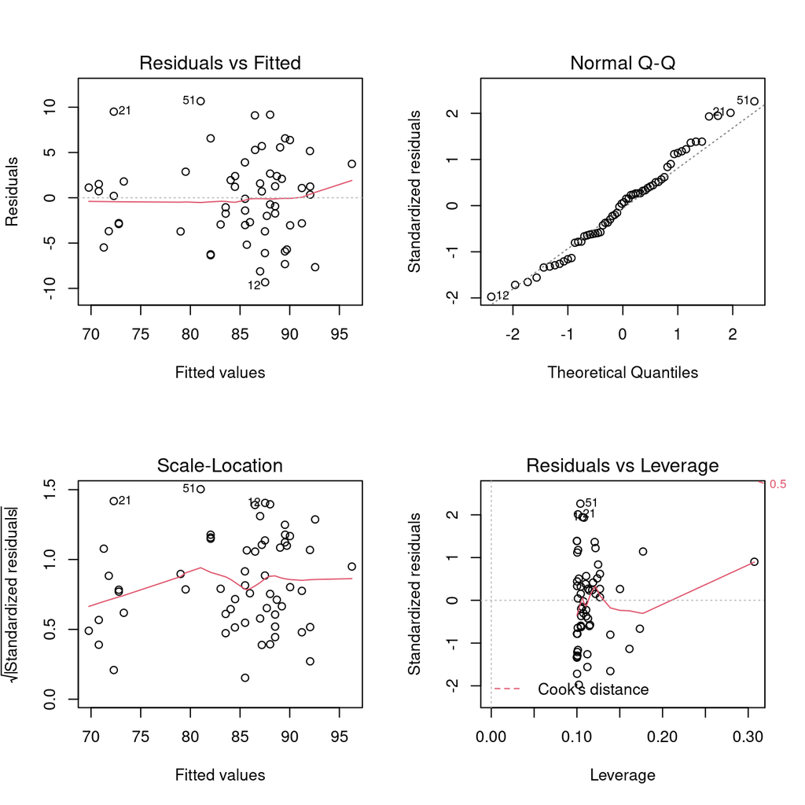

Figure 4: Gráficas de diagnóstico de `m3`.

```r
par(mfrow = c(2,2))
plot(m3)
```

Basándonos en las gráficas de la primera fila, podemos suponer que los residuales están bien contenidos, con la pequeña execpción de los residuales para el `score = 95`. Y para ver si esta desviación podría resultar en problemas para probar las hipótesis veamos la distribución de los residuales:

```r
shapiro.test(residuals(m3))
```

```
##
##  Shapiro-Wilk normality test
##
## data:  residuals(m3)
## W = 0.98226, p-value = 0.5313
```

Y vemos que sí es posible confiar, con base en los supuestos estadísticos del modelo ANCOVA en las pruebas de hipótesis pertinentes a `m3`:

1. El efecto del tratamiento depende de que se practique ejercicio (interacción)
2. La edad tenderá a incrementar los niveles de estrés, independientemente del tratamiento y ejercicio (efecto aditivo)

El script `ANCOVA-selección.R` tiene ejemplos de código para combinar los tipos de modelos vistos en esta unidad.

Regresar al índice del curso